# BIOS 545 - 2019 - Lecture 7: Functions Part 1

Ziyi Li (ziyi.li@emory.edu)

## Functions in R

- **Creating functions in R is very simple.**
- **Users communicate with R almost entirely through functions**
- **You should write a function whenever you find yourself going through the same sequence of steps at the command line, perhaps with small variations**
- **You can reuse code that you have found to be useful. You can even package it up and give it to others**
- **Once you have “trustworthy” code you can relax and not worry so much about errors**

### 1. A simple example to start with

#### A function to compute the square root of a number:

```r
# Version 1 - Simple Square root
myfunc <- function(somenum) {
     retval <- sqrt(somenum)
     return(retval)
}
```

### 2. What is function?

#### Functions are created using the function() directly and are stored as R objects just like anything else. In particular, they are R objects of class “function”.

```r
my.cool.function <- function(<arguments>) {
     ## Do something interesting
     ## Return a value(s)
}
```

- **Functions can be passed as arguments to other functions**
- **Functions can be nested, so that you can define a function inside of another function**
- **The return value of a function is the last expression in the function body to be evaluated.**
- **It is not necessary that a function return anything, for example a function that makes a plot might not return anything, whereas a function that does a mathematical operation might return a number, or a list.**

#### Let’s look at some formal definitions

```r
my.func <- function(arglist) {
     expr
     return(value) # You should have only ONE return statement
}
```

`arglist`: Empty or one or more name or name=expression terms

`expr`: Some statements / expressions

`value`: A computed expression to be returned

```r
my.func <- function(somenum) {
     my.return.val <- sqrt(somenum)
     return(my.return.val)
}
my.func(10)
```

```
## [1] 3.162278
```

```r
mycomputation <- my.func(10)
mycomputation
```

```
## [1] 3.162278
```

#### Reminder: Note that once you create a function you can retrieve its contents and edit it using the fix function. But better to use the Edit Window in RStudio. Change your function over time and reload it to register new versions by highlighting it and clicking “Run”

[figure not shown]

### 3.Some guidelines for writing functions

- **You should have only one return statement per function**
- **It should generally be the very last statement in the function**
- **A return is not strictly required although it is recommended**
- **You can return a vector, list, matrix, or data frame**
- **A list provides the most generality but it might be too much, depending on what it is you want to accomplish**
- **If you want to return data of different types then returning a list is your only choice (e.g. look at the results from the `lm()` function)**

### 4. Re-visit our square root function

```r
# Version 1 - Simple Square root
myfunc <- function(somenum) {
     retval <- sqrt(somenum)
     return(retval)
}

# Version 2 - Square root and complex numbers
myfunc1 <- function(somenum) {
     if (somenum < 0 ) {
          retval <- sqrt(as.complex(somenum))
     } else {
          retval <- sqrt(somenum)
     }
     return(retval)
}

# Version 3 - Provide and argument to select complex capability or not
myfunc2 <- function(somenum,complex="n") {
     if (somenum < 0 & complex == "n") {
          stop("HEY !! - Cannot take square root of negative number")
     } else if (somenum < 0 & complex == "y") {
          retval <- sqrt(as.complex(somenum))
     } else {
          retval <- sqrt(somenum)
     }
     return(retval)
}
```

### 5. Existing functions in R environment

#### There are many existing functions loaded in the environment. In general its easy to see the function definitions of many R functions.

#### Simply type their name

```r
ls
```

```
## function (name, pos = -1L, envir = as.environment(pos), all.names = FALSE,
##     pattern, sorted = TRUE)
## {
##     if (!missing(name)) {
##         pos <- tryCatch(name, error = function(e) e)
##         if (inherits(pos, "error")) {
##             name <- substitute(name)
##             if (!is.character(name))
##                 name <- deparse(name)
##             warning(gettextf("%s converted to character string",
##                 sQuote(name)), domain = NA)
##             pos <- name
##         }
##     }
##     all.names <- .Internal(ls(envir, all.names, sorted))
##     if (!missing(pattern)) {
##         if ((ll <- length(grep("[", pattern, fixed = TRUE))) &&
##             ll != length(grep("]", pattern, fixed = TRUE))) {
##             if (pattern == "[") {
##                 pattern <- "\\["
##                 warning("replaced regular expression pattern '[' by  '\\\\['")
##             }
##             else if (length(grep("[^\\\\]\\[<-", pattern))) {
##                 pattern <- sub("\\[<-", "\\\\\\[<-", pattern)
##                 warning("replaced '[<-' by '\\\\[<-' in regular expression pattern")
##             }
##         }
##         grep(pattern, all.names, value = TRUE)
##     }
##     else all.names
## }
## <bytecode: 0x7f81900ff1f0>
## <environment: namespace:base>
```

```r
head(base:::ls)  ## ls function comes from the package called base
```

```
##
## 1 function (name, pos = -1L, envir = as.environment(pos), all.names = FALSE,
## 2     pattern, sorted = TRUE)
## 3 {
## 4     if (!missing(name)) {
## 5         pos <- tryCatch(name, error = function(e) e)
## 6         if (inherits(pos, "error")) {
```

#### Sometimes its not so easy to see the contents and you have to hunt for them

```r
t.test
```

```
## function (x, ...)
## UseMethod("t.test")
## <bytecode: 0x7f818f637a58>
## <environment: namespace:stats>
```

```r
# Aha ! "t.test" is a S3-method and you can have a look at implemented
# methods on objects by doing:
methods(t.test)
```

```
## [1] t.test.default* t.test.formula*
## see '?methods' for accessing help and source code
```

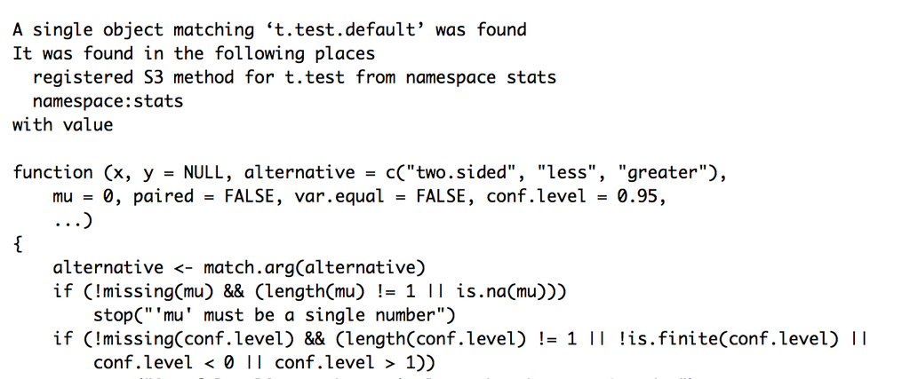

```r
# Sometimes it is not so easy to see the contents and you have to hunt for
# them
getAnywhere(t.test.default)
```

#### Use the args and example commands to get more info. Of course use the “?” to get even more help

```r
args(ls)
```

```
## function (name, pos = -1L, envir = as.environment(pos), all.names = FALSE,
##     pattern, sorted = TRUE)
## NULL
```

```r
example(sum)
```

```
##
## sum> ## Pass a vector to sum, and it will add the elements together.
## sum> sum(1:5)
## [1] 15
##
## sum> ## Pass several numbers to sum, and it also adds the elements.
## sum> sum(1, 2, 3, 4, 5)
## [1] 15
##
## sum> ## In fact, you can pass vectors into several arguments, and everything gets added.
## sum> sum(1:2, 3:5)
## [1] 15
##
## sum> ## If there are missing values, the sum is unknown, i.e., also missing, ....
## sum> sum(1:5, NA)
## [1] NA
##
## sum> ## ... unless  we exclude missing values explicitly:
## sum> sum(1:5, NA, na.rm = TRUE)
## [1] 15
```

### 6. How to write R function efficiently

#### Determine what you are being asked to do. This is easy for purposes of this class. You will be told:

- **What the function will accept as input (e.g. vector, matrix, data frame)**
- **What arguments the function will accept**
- **What to return - what the output will be**
- **Make a shell like the following and build into it:**

```r
myfunc <- function(somevec) {
     # Code goes here
}
```

#### Define a function called “pythag” that, given the two side lengths of a triangle, will compute the length of the third side

```r
pythag <- function(a,b) {
     c <- sqrt(a^2 + b^2)
     return(c)
}
pythag(4,5)
```

```
## [1] 6.403124
```

```r
x <- 4
y <- 5
pythag(x,y)
```

```
## [1] 6.403124
```

```r
pythag(a = 4, b = 5)
```

```
## [1] 6.403124
```

### 7. Return of functions

#### We can return pretty much any kind of R structure we would like. If you remember from the section on lists this is, in part, why lists exist. To let you return a number of things in a single structure. Recall that the `lm` function does this.

```r
data(mtcars)
my.lm <- lm(mpg ~ wt, data = mtcars)
typeof(my.lm)
```

```
## [1] "list"
```

```r
ls(my.lm)
```

```
##  [1] "assign"        "call"          "coefficients"  "df.residual"
##  [5] "effects"       "fitted.values" "model"         "qr"
##  [9] "rank"          "residuals"     "terms"         "xlevels"
```

```r
my.lm$call
```

```
## lm(formula = mpg ~ wt, data = mtcars)
```

```r
my.lm$rank
```

```
## [1] 2
```

#### Similarly, you can create such structures also

```r
pythag <- function(a,b) {
     c <- sqrt(a^2 + b^2)
     myreturnlist <- list(hypoteneuse = c, sidea = a, sideb = b)
     return(myreturnlist)
}
pythag(3,4) # We get back a list
```

```
## $hypoteneuse
## [1] 5
##
## $sidea
## [1] 3
##
## $sideb
## [1] 4
```

### 8. Error checking in functions

#### What happens if you give the function some bad stuff ?

```r
pythag(3,"a")
```

```
## Error in b^2: non-numeric argument to binary operator
```

```r
pythag()
```

```
## Error in pythag(): argument "a" is missing, with no default
```

```r
pythag(3,)
```

```
## Error in pythag(3, ): argument "b" is missing, with no default
```

#### You could set some default values:

```r
pythag <- function(a = 4, b = 5) {
     c <- sqrt(a^2 + b^2)
     myreturnlist <- list(hypoteneuse = c, sidea = a, sideb = b)
     return(myreturnlist)
}
pythag()
```

```
## $hypoteneuse
## [1] 6.403124
##
## $sidea
## [1] 4
##
## $sideb
## [1] 5
```

#### Maybe we should so some error checking in our function:

```r
pythag <- function(a = 4, b = 5) {
     if (!is.numeric(a) | !is.numeric(b)) {
          stop("I need real values to make this work")
     }
     c <- sqrt(a^2 + b^2)
     myreturnlist <- list(hypoteneuse = c, sidea = a, sideb = b)
     return(myreturnlist)
}
pythag(3,"5")
```

```
## Error in pythag(3, "5"): I need real values to make this work
```

```r
pythag("3",5)
```

```
## Error in pythag("3", 5): I need real values to make this work
```

#### Another way to do error checking:

```r
pythag <- function(a = 4, b = 5) {
     if (!is.numeric(a) | !is.numeric(b)) {
          stop("I need real values to make this work")
     }
     if (a <=0 | b <= 0) {
          stop("Arguments need to be positive")
     }
     c <- sqrt(a^2 + b^2)
     myreturnlist <- list(hypoteneuse = c, sidea = a, sideb = b)
     return(myreturnlist)
} # End Function
pythag(-3,3)
```

```
## Error in pythag(-3, 3): Arguments need to be positive
```

```r
pythag(3,3)
```

```
## $hypoteneuse
## [1] 4.242641
##
## $sidea
## [1] 3
##
## $sideb
## [1] 3
```

#### Always create a function whenever you have some block of code that works well. This will prevent you from having to type it in the code every time you wish to execute it.

#### It can be edited over time as you need to make changes to it. Functions don’t need to be complicated to be useful.

```r
# Utility function to determine if a value is odd or even
is.odd <- function(someval) {
     retval <- 0 # Set the return value to a default
     if (someval %% 2 != 0) {
          retval <- TRUE
     } else {
          retval <- FALSE
     }
     return(retval)
}
is.odd(3)
```

```
## [1] TRUE
```

#### Before creating a function, ask yourself what are the

- **input(s) ? (e.g. single value, vector, matrix, data frame)**
- **output(s) ? (e.g. single value, vector, matrix, etc)**

```r
# Utility function to determine if a value is odd or even
is.odd <- function(someval) {
     retval <- 0 # Set the return value to a default
     if (someval %% 2 != 0) {
          retval <- TRUE
     } else {
          retval <- FALSE
     }
     return(retval)
} # End function
```

#### This works on single values. It could be changed to work with single values or vectors

```r
is.odd <- function(someval) {
     retvec <- vector()
     for (ii in 1:length(someval)) {
          if (someval[ii] %% 2 != 0) {
             retvec[ii] <- TRUE
          } else {
            retvec[ii] <- FALSE
          }
     }
     return(retvec)
} # End function
is.odd(3)
```

```
## [1] TRUE
```

```r
numbers <- c(9,9,4,4,6,10,7,18,2,10)
is.odd(numbers)
```

```
##  [1]  TRUE  TRUE FALSE FALSE FALSE FALSE  TRUE FALSE FALSE FALSE
```

```r
numbers[is.odd(numbers)] # Very useful
```

```
## [1] 9 9 7
```

### 9. Example: create a function to plot

#### Let’s look at some of the structures from previous week to see how they might look as functions. We used the following approach to take a series of X values, plug them into a function to get resulting Y values, and then plot them.

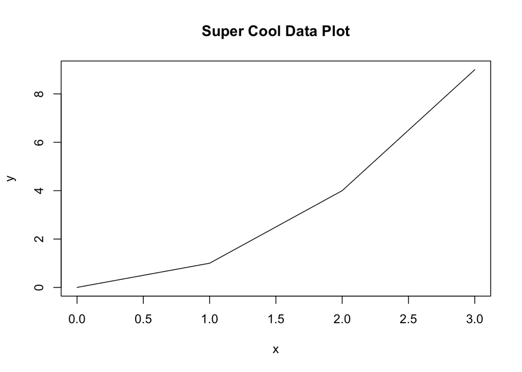

```r
y <- vector()
x <- seq(0,3)
for (ii in 1:length(x)) {
     y[ii] <- (x[ii])^2
}
plot(x,y,main="Super Cool Data Plot",type="l")
```

#### Let’s look at some of the structures from last week to see how they might look as functions. We can even make an argument for an arbitrary y function

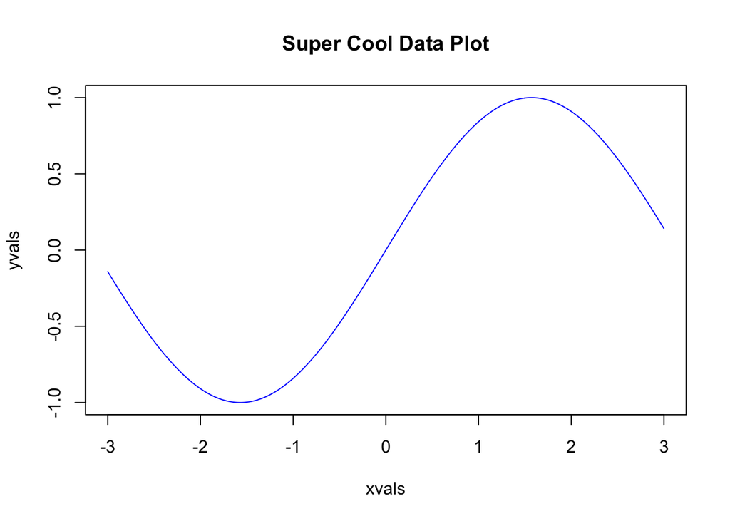

```r
myplotter <- function(xvals, mfunc) { # begin function

# Function at which to evaluate each x (must be valid)
# Input: xvalues - a vector
# : mfunc - a function to apply to each value of xvalues
# Output: A plot

     yvals <- vector() # setup a blank vector to hold y-values
     for (ii in 1:length(xvals)) { # begin for loop
          yvals[ii] <- mfunc(xvals[ii])
     } # end for loop
     plot(xvals, yvals, main="Super Cool Data Plot",type="l",col="blue")

} # End function

# Let's look at some of the structures from last week to see how they might
# look as functions. We can even make an argument for a function

xvals <- seq(-3,3,0.005)

myplotter(xvals,sin)
```

#### We could add in “arguments” to influence the color of the plot. We could also return the generated y values if we wanted to.

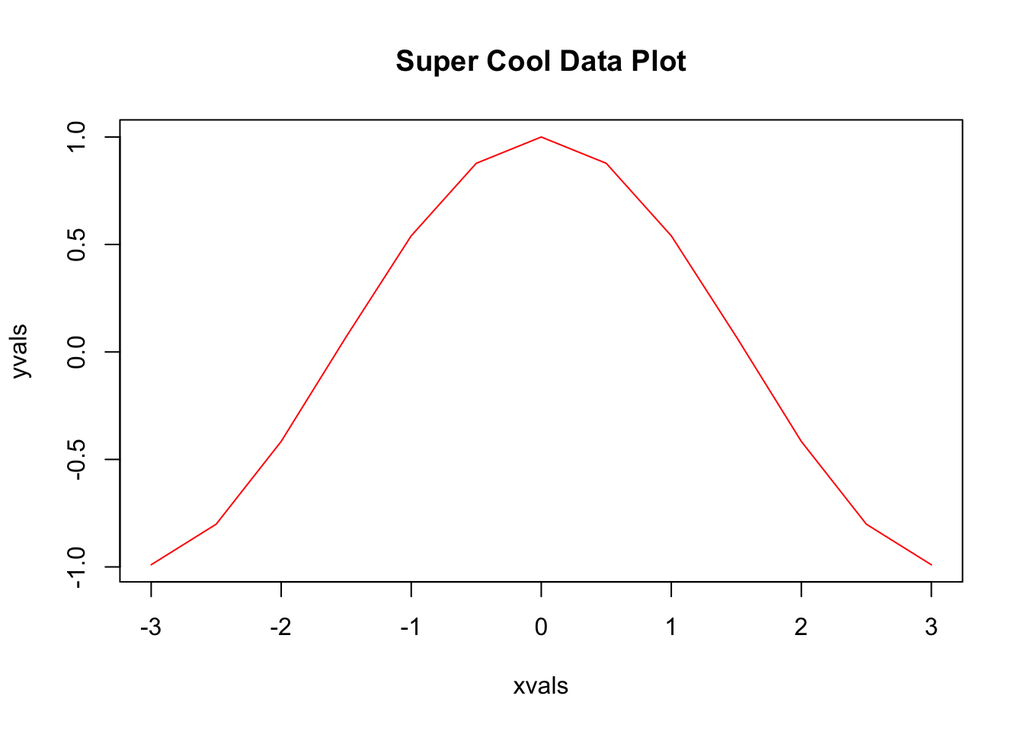

```
## $x
##  [1] -3.0 -2.5 -2.0 -1.5 -1.0 -0.5  0.0  0.5  1.0  1.5  2.0  2.5  3.0
##
## $y
##  [1] -0.9899925 -0.8011436 -0.4161468  0.0707372  0.5403023  0.8775826
##  [7]  1.0000000  0.8775826  0.5403023  0.0707372 -0.4161468 -0.8011436
## [13] -0.9899925
```

```r
myplotter <- function(xvals, mfunc, plotcolor="blue") {

     # Function at which to evaluate each x (must be valid)
     # Input: xvalues - a vector of values
     # : mfunc - a function to apply to xvalues
     # : plotcolor - the color used when plotting
     # Output: A plot and the xvals and yvals used to make that plot

     yvals <- vector()
     for (ii in 1:length(xvals)) {
          yvals[ii] <- mfunc(xvals[ii])
     }
     plot(xvals, yvals, main="Super Cool Data Plot",type="l",col=plotcolor)
     retlist <- list(x=xvals, y=yvals)
     return(retlist)
}

xvals <- seq(-3,3,0.5)

myplotter(xvals,cos,plotcolor="red")
```

### 10. Example: a function that find the minimun value in a vector

#### Take this from last week and make it a function.

```r
set.seed(188)
somevector <- rnorm(1000) # 1,000 random elements from a N(20,4)

mymin <- somevector[1] # Set the minimum to an arbitrary value
     for (ii in 1:length(x)) {
          if (x[ii] < mymin) {
          mymin <- x[ii]
     }
     }

mymin
```

```
## [1] -1.636777
```

```r
# Write a function that finds the minimum value in a vector. Take this from
# last week and make it a function.

mymin <- function(somevector) {

     # Function to find the minimum value in a vector
     # Input: somevector - A numeric vector
     # Output: A single value that represents the minimum
     mymin <- somevector[1] # Set the minimum to an arbitrary value

     # Now loop through the entire vector. If we find a value less than
     # mymin then we set mymin to be that value.
     for (ii in 1:length(somevector)) {
          if (somevector[ii] < mymin) {
               mymin <- somevector[ii]
          }
     }
     return(mymin)
}

set.seed(123)
testvec <- rnorm(10000)

mymin(testvec)
```

```
## [1] -3.84532
```

```r
min(testvec) # Matches the built in R function
```

```
## [1] -3.84532
```

#### Let’s make an argument that let’s us specify the min or max

```r
myextreme <- function(somevector, action="min") {
     if (action == "min") {
          myval <- somevector[1] # Set the minimum to an arbitrary value
          for (ii in 1:length(somevector)) {
               if (somevector[ii] < myval) {
                    myval <- somevector[ii]
               }
          } # End for
     } else { # If action is not "min" then we assume the "max" is wanted
          myval <- somevector[1] # Set the maximum to an arbitrary value
          for (ii in 1:length(somevector)) {
               if (somevector[ii] > myval) {
                    myval <- somevector[ii]
               }
          } # End for
     } # End If
     return(myval)
}
```

#### Last time we looked at for-loops to process data frames that we had split up by a factor:

```r
mysplits <- split(mtcars, mtcars$cyl)
for (ii in 1:length(mysplits)) {
     cat("Split ",names(mysplits)[ii]," has ",
     nrow(mysplits[[ii]]),"rows \n")
}
```

```
## Split  4  has  11 rows
## Split  6  has  7 rows
## Split  8  has  14 rows
```

```r
myfunc <- function(somedf, somefac) {
     # Function to split a data frame by a given factor
     # Input: somedf - A data frame, somefac - a factor by which to split somedf
     # Output: A list containing a count of records in each group

     retlist <- list() # Empty list to return group record count
     mysplits <- split(somedf,somefac) # Split the data frame by somefac
     for (ii in 1:length(mysplits)) { # loop through the splits
          retlist[[ii]] <- nrow(mysplits[[ii]])
     }
     names(retlist) <- names(mysplits)
     return(retlist)
}

myfunc(mtcars,mtcars$cyl)
```

```
## $`4`
## [1] 11
##
## $`6`
## [1] 7
##
## $`8`
## [1] 14
```

#### It is worth it to note that the previous function could be rewritten using the `lapply` function

```r
myfunc <- function(somedf, somefac) {
     # Function to split a data frame by a given factor
     # Input: somedf - A data frame, somefac - a factor by which to split somedf
     # Output: A list containing a count of records in each group

     mysplits <- split(somedf,somefac)
     return(lapply(mysplits,function(x) nrow(x)))
}

myfunc(mtcars,mtcars$am)
```

```
## $`0`
## [1] 19
##
## $`1`
## [1] 13
```

- **Anonymous functions are those that are created for “one-off” jobs.**
- **They usually show up when using the apply family of functions(lapply, apply, and sapply).**
- **Think of anonymous functions as being temporary. We don’t even bother to name them but they still behave just like any other function.**

```r
my.mat <- as.matrix(mtcars[,c(1,3:6)])
head(my.mat)
```

```
##                    mpg disp  hp drat    wt
## Mazda RX4         21.0  160 110 3.90 2.620
## Mazda RX4 Wag     21.0  160 110 3.90 2.875
## Datsun 710        22.8  108  93 3.85 2.320
## Hornet 4 Drive    21.4  258 110 3.08 3.215
## Hornet Sportabout 18.7  360 175 3.15 3.440
## Valiant           18.1  225 105 2.76 3.460
```

```r
# In this example we call the mean function on all the columns in the matrix.
# Note that the mean function isn't anonymous. It has a name.

apply(my.mat,2, mean)
```

```
##        mpg       disp         hp       drat         wt
##  20.090625 230.721875 146.687500   3.596563   3.217250
```

```r
# But what if we wanted to provide our own custom function ? Well we
# could write one in advance and then use it with apply. Here we write a
# function to sum all elements in a vector.

mysum <- function(x) {
     return(sum(x))
}
# We now use it to sum each colum in the matrix
apply(my.mat,2,mysum)
```

```
##      mpg     disp       hp     drat       wt
##  642.900 7383.100 4694.000  115.090  102.952
```

```r
# But since this function is so simple we could define it as we make the call
# to apply.
apply(my.mat, 2, function(x) sum(x))
```

```
##      mpg     disp       hp     drat       wt
##  642.900 7383.100 4694.000  115.090  102.952
```

```r
# This function lives only for the length of the call to apply. It is so
# "temporary" that we don't even bother to give it a name so it is an
# anonymous function.

my.mat <- as.matrix(mtcars[,c(1,3:6)])

head(my.mat)
```

```
##                    mpg disp  hp drat    wt
## Mazda RX4         21.0  160 110 3.90 2.620
## Mazda RX4 Wag     21.0  160 110 3.90 2.875
## Datsun 710        22.8  108  93 3.85 2.320
## Hornet 4 Drive    21.4  258 110 3.08 3.215
## Hornet Sportabout 18.7  360 175 3.15 3.440
## Valiant           18.1  225 105 2.76 3.460
```

```r
apply(my.mat,2, function(x) {c(mean=mean(x),sd=sd(x),range=range(x))})
```

```
##              mpg     disp        hp      drat        wt
## mean   20.090625 230.7219 146.68750 3.5965625 3.2172500
## sd      6.026948 123.9387  68.56287 0.5346787 0.9784574
## range1 10.400000  71.1000  52.00000 2.7600000 1.5130000
## range2 33.900000 472.0000 335.00000 4.9300000 5.4240000
```

#### In my opinion it is better to first define the function before using it. I feel that this makes it easier since you can fully test and debug the function independently of the apply command.

```r
mysummary <- function(x) {
     retvec <- c(mean=mean(x),sd=sd(x),range=range(x))
     return(retvec)
}
apply(my.mat,2,mysummary)
```

```
##              mpg     disp        hp      drat        wt
## mean   20.090625 230.7219 146.68750 3.5965625 3.2172500
## sd      6.026948 123.9387  68.56287 0.5346787 0.9784574
## range1 10.400000  71.1000  52.00000 2.7600000 1.5130000
## range2 33.900000 472.0000 335.00000 4.9300000 5.4240000
```